# Analyses

# Set-up

## Packages

```r
library(brms)
library(ggplot2)
library(kableExtra)
library(lme4)
library(lmerTest)
library(rmarkdown)
library(naniar)
library(performance)
library(see)
library(sjmisc)
library(tidyverse)

options(
  digits = 3
)
set.seed(170819)
```

## Custom functions

```r
# function to silence brms output
hush <-
  function(
    code
    ){
    sink("/dev/null")
    tmp = code
    sink()
    return(tmp)
    }
```

## Data

```r
d <- read_csv("data/data.csv")

# same as above; but original file name:
# d <- read_csv("data/DataAggregated_T1T2_costsbenefits.csv")

# load image for work in IDE
# load("data/image.RData")

d <- d |>
  rename(
    group = roles,
    op_expr = n_OE,
    gender = DE01_T1,
    age = DE02_01_T1,
    pol_stance = DE06_01_T1
  ) |>
  mutate(
    female = as.logical(2 - gender),
    gender = factor(gender, labels = c("female", "male"))
  )

# recode to make as sum coding
d$anonymity_dev <- factor(d$anonymity)
contrasts(d$anonymity_dev) <- contr.sum(2)
d$persistence_dev <- factor(d$persistence)
contrasts(d$persistence_dev) <- contr.sum(2)
```

# Missing data

Let’s first inspect how much data is missing

```r
# Filter variables used for analyses
d_filt <- d |>
  select(age, gender, pol_stance, topic, persistence, persistence_dev, anonymity, anonymity_dev, op_expr)

# Summary
miss_var_summary(d_filt)       # % missing per variable
```

```
# A tibble: 9 × 3
  variable        n_miss pct_miss
  <chr>            <int>    <num>
1 age                  0        0
2 gender               0        0
3 pol_stance           0        0
4 topic                0        0
5 persistence          0        0
6 persistence_dev      0        0
7 anonymity            0        0
8 anonymity_dev        0        0
9 op_expr              0        0
```

```r
miss_case_summary(d_filt)      # % missing per row
```

```
# A tibble: 960 × 3
    case n_miss pct_miss
   <int>  <int>    <dbl>
 1     1      0        0
 2     2      0        0
 3     3      0        0
 4     4      0        0
 5     5      0        0
 6     6      0        0
 7     7      0        0
 8     8      0        0
 9     9      0        0
10    10      0        0
# ℹ 950 more rows
```

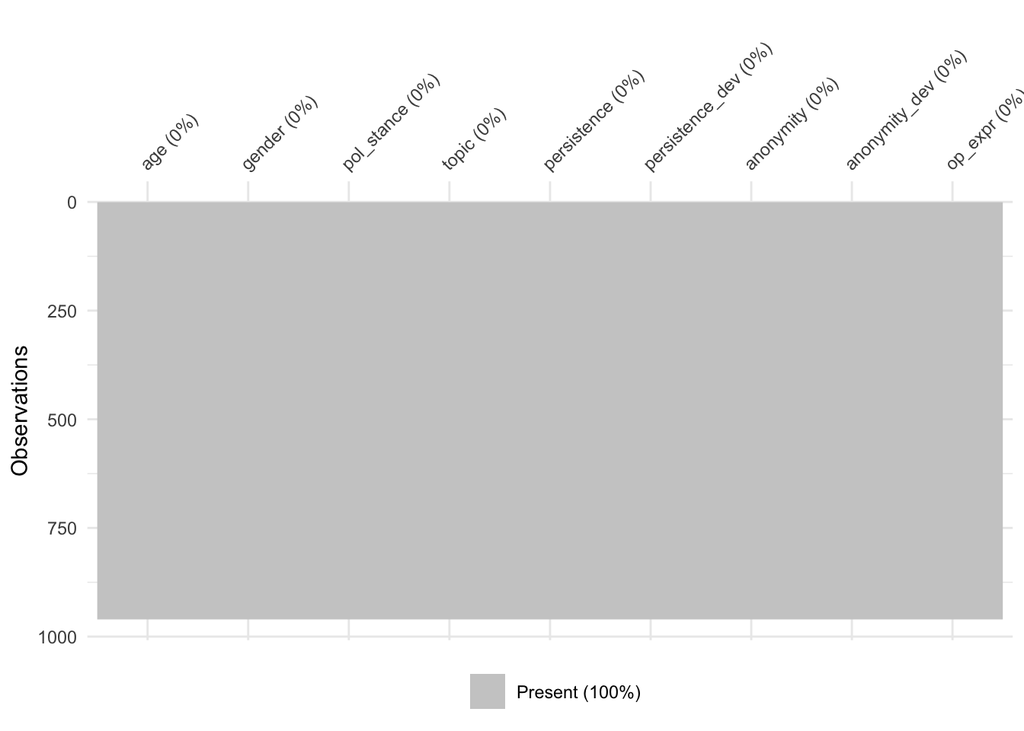

```r
# Visualization
vis_miss(d_filt)               # Heatmap of missingness
```

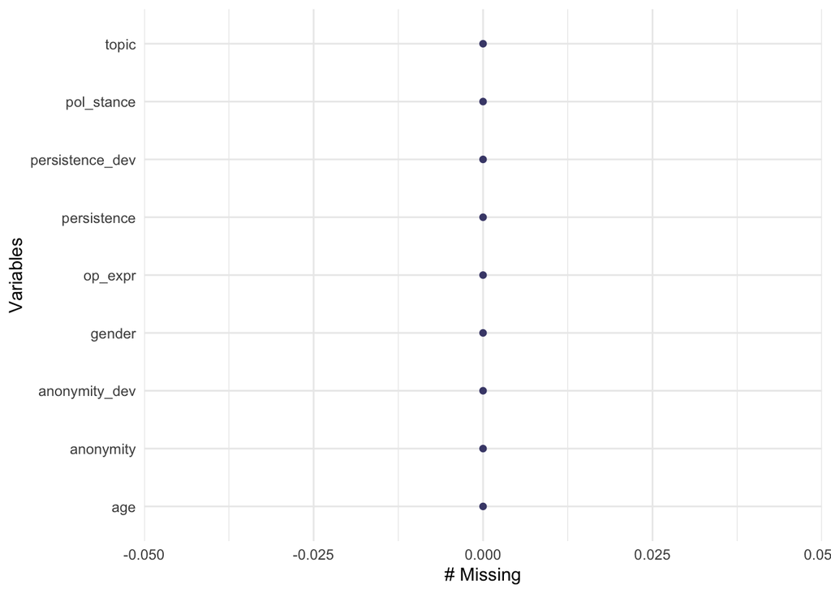

```r
gg_miss_var(d_filt)            # Bar plot: missing per variable
```

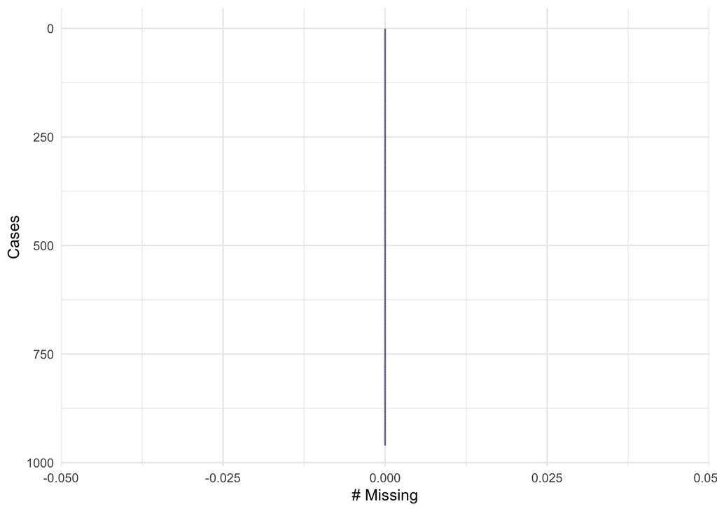

```r
gg_miss_case(d_filt)           # Bar plot: missing per case
```

Shows that there are nore missing data for the variables we’ll analyse. Hence, no imputing necessary.

# Descriptives

Let’s inspect distribution of opinion expressions.

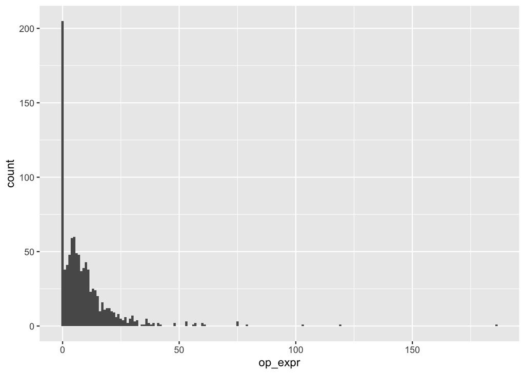

```r
ggplot(d, aes(op_expr)) +
  geom_histogram(binwidth = 1)
```

Looks like a zero-inflated poisson distribution. Confirms our preregistered approach to analyze data using zero-inflated Poisson approach.

```r
nrow(d[d$op_expr == 0, ]) / nrow(d)
```

```
[1] 0.214
```

Overall, 21% of participants without any opinion expressions.

Let’s look at distribution of experimental groups.

```r
d |>
  select(persistence, anonymity) |>
  table()
```

```
           anonymity
persistence high low
       high  240 240
       low   240 240
```

Distribution among groups perfect.

```r
d |>
  select(topic) |>
  table()
```

```
topic
  climate    gender migration
      320       320       320
```

Distribution of topics also perfect.

Let’s check if groups are nested in topics:

```r
is_nested(d$topic, d$group)
```

```
'f2' is nested within 'f1'
```

```
[1] TRUE
```

Indeed the case.

We first look at the experimental group’s descriptives

```r
d |>
  group_by(persistence) |>
  summarize(op_expr_m = mean(op_expr)) |>
  as.data.frame() |>
  kable()
```

| persistence | op_expr_m |
| --- | --- |
| high | 9.26 |
| low | 9.29 |

Looking at persistence, we see there’s virtually no difference among groups.

```r
d |>
  group_by(anonymity) |>
  summarize(op_expr_m = mean(op_expr)) |>
  as.data.frame() |>
  kable()
```

| anonymity | op_expr_m |
| --- | --- |
| high | 9.03 |
| low | 9.52 |

People who with *less* anonymity communicated *more*. But the difference isn’t particularly large.

```r
d |>
  group_by(persistence, anonymity) |>
  summarize(op_expr_m = mean(op_expr)) |>
  as.data.frame() |>
  kable()
```

| persistence | anonymity | op_expr_m |
| --- | --- | --- |
| high | high | 9.27 |
| high | low | 9.25 |
| low | high | 8.79 |
| low | low | 9.78 |

Looking at both groups combined, we see that low anonymity and low persistence created highest participation. But differences among groups aren’t large.

```r
d |>
  group_by(group) |>
  summarize(
    anonymity = anonymity[1],
    persistence = persistence[1],
    topic = topic[1],
    op_expr_m = mean(op_expr)
    ) |>
  rmarkdown::paged_table()
```

| group | anonymity | persistence | topic | op_expr_m |
| --- | --- | --- | --- | --- |
| Berlin1 | low | high | migration | 7.05 |
| Berlin2 | low | high | migration | 5.35 |
| Berlin3 | low | high | migration | 6.05 |
| Berlin4 | low | high | migration | 22.40 |
| Dubai1 | high | low | gender | 3.95 |
| Dubai2 | high | low | gender | 8.60 |
| Dubai3 | high | low | gender | 7.10 |
| Dubai4 | high | low | gender | 10.30 |
| Florenz1 | high | high | migration | 4.80 |
| Florenz2 | high | high | migration | 8.30 |

[output cut: 38 more lines]

Looking at the various individual groups, we do see some difference. Generally, this shows that communication varied across groups.

```r
d |>
  group_by(topic) |>
  summarize(op_expr_m = mean(op_expr)) |>
  as.data.frame() |>
  kable()
```

| topic | op_expr_m |
| --- | --- |
| climate | 9.63 |
| gender | 9.96 |
| migration | 8.22 |

Looking at topics specifically, we also see that there’s some variance.

## Opinion expressions

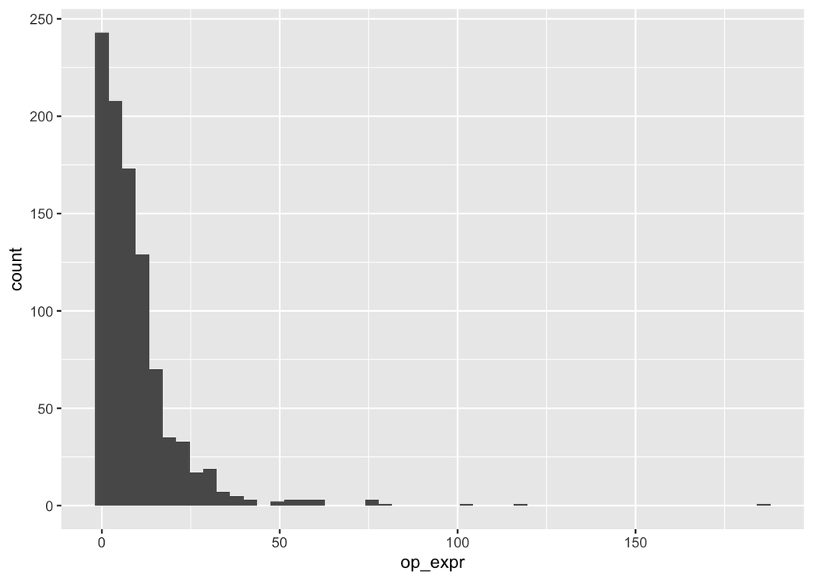

```r
ggplot(d, aes(op_expr)) +
  geom_histogram(bins = 50)
```

Let’s also look at how many did not express any opinions at all.

Number:

```r
length(which(d$op_expr == 0))
```

```
[1] 205
```

Percentage:

```r
length(which(d$op_expr == 0)) / length(d$op_expr)
```

```
[1] 0.214
```

Stats:

```r
summary(d$op_expr)
```

```
   Min. 1st Qu.  Median    Mean 3rd Qu.    Max.
    0.0     1.0     6.0     9.3    12.0   186.0
```

## Communicated words

Let’s look at the distribution of communicated number of words.

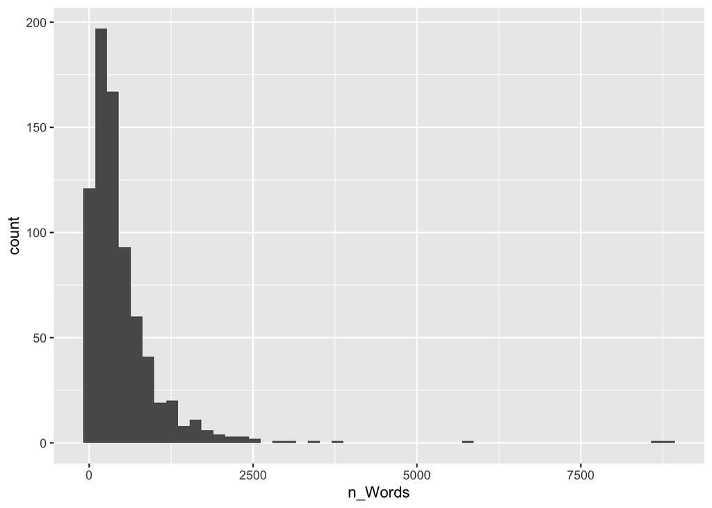

```r
ggplot(d, aes(n_Words)) +
  geom_histogram(bins = 50)
```

Let’s also look at how many did not write any words at all.

```r
length(which(d$n_Words == 0))
```

```
[1] 0
```

Everyone wrote at least one word.

Stats:

```r
summary(d$n_Words)
```

```
   Min. 1st Qu.  Median    Mean 3rd Qu.    Max.    NA's
      1     149     336     496     602    8843     198
```

# Manipulation Check

Let’s see if respondents indeed perceived the experimental manipulations. Let’s first look at descriptives.

```r
d |>
  group_by(persistence) |>
  summarize(
    "Perceived persistence" = mean(per_persistence, na.rm = TRUE)
    ) |>
  as.data.frame() |>
  kable()
```

| persistence | Perceived persistence |
| --- | --- |
| high | 1.78 |
| low | 4.19 |

The experimental manipulation worked.

```r
model_pers <- lm(
  per_persistence ~ persistence_dev,
  d
)

summary(model_pers)
```

```
Call:
lm(formula = per_persistence ~ persistence_dev, data = d)

Residuals:
   Min     1Q Median     3Q    Max
-3.194 -0.777 -0.110  0.806  3.223

Coefficients:
                 Estimate Std. Error t value Pr(>|t|)
(Intercept)        2.9854     0.0378    79.1   <2e-16 ***
persistence_dev1  -1.2085     0.0378   -32.0   <2e-16 ***
---
Signif. codes:  0 '***' 0.001 '**' 0.01 '*' 0.05 '.' 0.1 ' ' 1

Residual standard error: 1 on 703 degrees of freedom
  (255 observations deleted due to missingness)
Multiple R-squared:  0.593, Adjusted R-squared:  0.592
F-statistic: 1.02e+03 on 1 and 703 DF,  p-value: <2e-16
```

The difference was statistically significant. Let’s now look at anonymity.

```r
d |>
  group_by(anonymity) |>
  summarize(
    "Perceived anonymity" = mean(per_anonymity, na.rm = TRUE)
    ) |>
  as.data.frame() |>
  kable()
```

| anonymity | Perceived anonymity |
| --- | --- |
| high | 1.22 |
| low | 4.42 |

The experimental manipulation worked.

```r
model_anon <- lm(
  per_anonymity ~ anonymity_dev,
  d
)
summary(model_anon)
```

```
Call:
lm(formula = per_anonymity ~ anonymity_dev, data = d)

Residuals:
   Min     1Q Median     3Q    Max
-3.425 -0.216 -0.216  0.575  3.784

Coefficients:
               Estimate Std. Error t value Pr(>|t|)
(Intercept)      2.8204     0.0348    81.0   <2e-16 ***
anonymity_dev1  -1.6042     0.0348   -46.1   <2e-16 ***
---
Signif. codes:  0 '***' 0.001 '**' 0.01 '*' 0.05 '.' 0.1 ' ' 1

Residual standard error: 0.924 on 703 degrees of freedom
  (255 observations deleted due to missingness)
Multiple R-squared:  0.751, Adjusted R-squared:  0.751
F-statistic: 2.12e+03 on 1 and 703 DF,  p-value: <2e-16
```

The experimental manipulation worked.

## Cross contamination

Let’s look at cross contamination, i.e. if anonymity affected perceived persistence and if persistence affects perceived anonymity.

```r
d |>
  group_by(anonymity) |>
  summarize(
    "Perceived persistence" = mean(per_persistence, na.rm = TRUE)
    ) |>
  as.data.frame() |>
  kable()
```

| anonymity | Perceived persistence |
| --- | --- |
| high | 2.89 |
| low | 3.00 |

There was next to no difference among groups.

```r
model_pers <- lm(
  per_persistence ~ anonymity_dev,
  d
)

summary(model_pers)
```

```
Call:
lm(formula = per_persistence ~ anonymity_dev, data = d)

Residuals:
   Min     1Q Median     3Q    Max
-2.005 -1.671  0.108  1.662  2.108

Coefficients:
               Estimate Std. Error t value Pr(>|t|)
(Intercept)      2.9485     0.0591   49.86   <2e-16 ***
anonymity_dev1  -0.0561     0.0591   -0.95     0.34
---
Signif. codes:  0 '***' 0.001 '**' 0.01 '*' 0.05 '.' 0.1 ' ' 1

Residual standard error: 1.57 on 703 degrees of freedom
  (255 observations deleted due to missingness)
Multiple R-squared:  0.00128,   Adjusted R-squared:  -0.000141
F-statistic: 0.901 on 1 and 703 DF,  p-value: 0.343
```

The difference was not statistically significant. No cross contamination re. anonymity.

```r
d |>
  group_by(persistence) |>
  summarize(
    "Perceived anonymity" = mean(per_anonymity, na.rm = TRUE)
    ) |>
  as.data.frame() |>
  kable()
```

| persistence | Perceived anonymity |
| --- | --- |
| high | 2.76 |
| low | 2.93 |

There was next to no difference in the groups’ means.

```r
model_anon <- lm(
  per_anonymity ~ persistence_dev,
  d
)
summary(model_anon)
```

```
Call:
lm(formula = per_anonymity ~ persistence_dev, data = d)

Residuals:
   Min     1Q Median     3Q    Max
-1.933 -1.763 -0.763  2.067  2.237

Coefficients:
                 Estimate Std. Error t value Pr(>|t|)
(Intercept)        2.8479     0.0698   40.83   <2e-16 ***
persistence_dev1  -0.0848     0.0698   -1.22     0.22
---
Signif. codes:  0 '***' 0.001 '**' 0.01 '*' 0.05 '.' 0.1 ' ' 1

Residual standard error: 1.85 on 703 degrees of freedom
  (255 observations deleted due to missingness)
Multiple R-squared:  0.0021,    Adjusted R-squared:  0.00068
F-statistic: 1.48 on 1 and 703 DF,  p-value: 0.224
```

Again, no significant difference. In conclusion, no cross-contamination.

# Random Allocation

Let’s check if random allocation across experimental conditions worked alright. Let’s first look at descriptives.

```r
d |>
  group_by(persistence, anonymity) |>
  summarize(
    female_m = mean(female)
    , age_m = mean(age)
    , pol_stance_m = mean(pol_stance)
    ) |>
  as.data.frame() |>
  kable()
```

| persistence | anonymity | female_m | age_m | pol_stance_m |
| --- | --- | --- | --- | --- |
| high | high | 0.613 | 43.2 | 5.57 |
| high | low | 0.662 | 39.6 | 5.44 |
| low | high | 0.558 | 41.7 | 5.76 |
| low | low | 0.683 | 40.8 | 5.15 |

There seem to be some differences. Let’s inspect manually.

```r
model_persis <- lm(
  as.integer(persistence_dev) ~ age + gender + pol_stance,
  d
)
summary(model_persis)
```

```
Call:
lm(formula = as.integer(persistence_dev) ~ age + gender + pol_stance,
    data = d)

Residuals:
    Min      1Q  Median      3Q     Max
-0.5352 -0.4994 -0.0006  0.4994  0.5385

Coefficients:
             Estimate Std. Error t value Pr(>|t|)
(Intercept)  1.536577   0.072667   21.15   <2e-16 ***
age         -0.000632   0.001402   -0.45     0.65
gendermale   0.022885   0.034672    0.66     0.51
pol_stance  -0.003460   0.008089   -0.43     0.67
---
Signif. codes:  0 '***' 0.001 '**' 0.01 '*' 0.05 '.' 0.1 ' ' 1

Residual standard error: 0.501 on 956 degrees of freedom
Multiple R-squared:  0.000702,  Adjusted R-squared:  -0.00243
F-statistic: 0.224 on 3 and 956 DF,  p-value: 0.88
```

Allocation of gender, age, and political stance on the two persistence groups was successful.

```r
model_anon <- lm(
  as.integer(anonymity_dev) ~ age + gender + pol_stance,
  d
)
summary(model_anon)
```

```
Call:
lm(formula = as.integer(anonymity_dev) ~ age + gender + pol_stance,
    data = d)

Residuals:
    Min      1Q  Median      3Q     Max
-0.6702 -0.4902  0.0125  0.4874  0.7263

Coefficients:
            Estimate Std. Error t value Pr(>|t|)
(Intercept)  1.77558    0.07192   24.69   <2e-16 ***
age         -0.00323    0.00139   -2.33   0.0201 *
gendermale  -0.06686    0.03432   -1.95   0.0517 .
pol_stance  -0.02142    0.00801   -2.68   0.0076 **
---
Signif. codes:  0 '***' 0.001 '**' 0.01 '*' 0.05 '.' 0.1 ' ' 1

Residual standard error: 0.496 on 956 degrees of freedom
Multiple R-squared:  0.0211,    Adjusted R-squared:  0.018
F-statistic: 6.87 on 3 and 956 DF,  p-value: 0.00014
```

However, allocation across anonymity groups wasn’t successful. In the subsequent analyses, let’s hence control for these sociodemographic variables.

# Bayesian mixed effects modeling

We analyze the data using Bayesian modelling.

## Fixed effects

We preregistered to analyze fixed effects.

```r
fit_fe_1 <-
  hush(
    brm(
      op_expr ~
        1 + persistence_dev * anonymity_dev + age + female + pol_stance +
        (1 | topic/group)
      , data = d
      , chains = 4
      , cores = 4
      , iter = 6000
      , warmup = 2000
      , family = zero_inflated_poisson()
      , control = list(
        adapt_delta = .95
        , max_treedepth = 12
        )
      , save_pars = save_pars(all = TRUE)
      , silent = 2
      )
  )
```

```
Warning: There were 214 divergent transitions after warmup. See
https://mc-stan.org/misc/warnings.html#divergent-transitions-after-warmup
to find out why this is a problem and how to eliminate them.
```

```
Warning: Examine the pairs() plot to diagnose sampling problems
```

Shows some convergence warnings. Let’s inspect model.

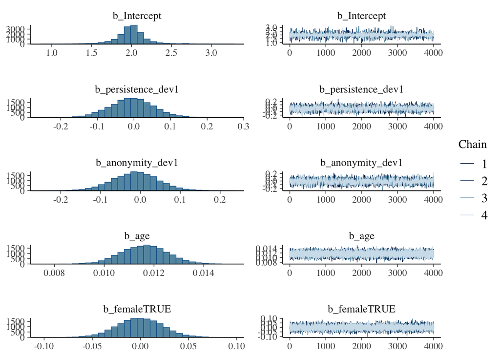

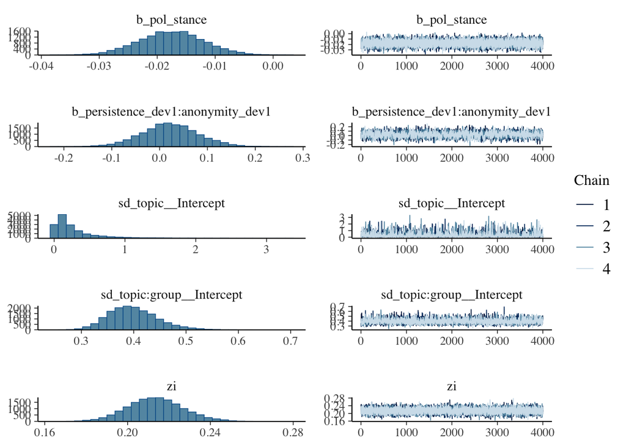

```r
plot(fit_fe_1, ask = FALSE)
```

Trace-plots look alright.

Let’s look at results.

```r
summary(fit_fe_1)
```

```
 Family: zero_inflated_poisson
  Links: mu = log; zi = identity
Formula: op_expr ~ 1 + persistence_dev * anonymity_dev + age + female + pol_stance + (1 | topic/group)
   Data: d (Number of observations: 960)
  Draws: 4 chains, each with iter = 6000; warmup = 2000; thin = 1;
         total post-warmup draws = 16000

Multilevel Hyperparameters:
~topic (Number of levels: 3)
              Estimate Est.Error l-95% CI u-95% CI Rhat Bulk_ESS Tail_ESS
sd(Intercept)     0.27      0.31     0.01     1.18 1.00     1935     4004

~topic:group (Number of levels: 48)
              Estimate Est.Error l-95% CI u-95% CI Rhat Bulk_ESS Tail_ESS
sd(Intercept)     0.40      0.05     0.32     0.50 1.00     2863     4835

Regression Coefficients:
                                Estimate Est.Error l-95% CI u-95% CI Rhat
Intercept                           1.99      0.20     1.56     2.43 1.00
persistence_dev1                   -0.01      0.06    -0.12     0.11 1.00
anonymity_dev1                     -0.01      0.06    -0.13     0.10 1.00
age                                 0.01      0.00     0.01     0.01 1.00
femaleTRUE                         -0.00      0.02    -0.05     0.05 1.00
pol_stance                         -0.02      0.01    -0.03    -0.01 1.00
persistence_dev1:anonymity_dev1     0.02      0.06    -0.09     0.14 1.00
                                Bulk_ESS Tail_ESS
Intercept                           3751     2124
persistence_dev1                    2818     4655
anonymity_dev1                      2685     5035
age                                22907    13685
femaleTRUE                          9989    10431
pol_stance                         11560    10620
persistence_dev1:anonymity_dev1     2773     4109

Further Distributional Parameters:
   Estimate Est.Error l-95% CI u-95% CI Rhat Bulk_ESS Tail_ESS
zi     0.21      0.01     0.19     0.24 1.00    10401     9549

Draws were sampled using sampling(NUTS). For each parameter, Bulk_ESS
and Tail_ESS are effective sample size measures, and Rhat is the potential
scale reduction factor on split chains (at convergence, Rhat = 1).
```

No significant effect emerged.

Let’s inspect ICC

```r
var_ratio_fe <- performance::variance_decomposition(
  fit_fe_1
  , by_group = TRUE)
var_ratio_fe
```

```
# Random Effect Variances and ICC

Conditioned on: all random effects

## Variance Ratio (comparable to ICC)
Ratio: 0.42  CI 95%: [-0.24 0.72]

## Variances of Posterior Predicted Distribution
Conditioned on fixed effects: 31.94  CI 95%: [15.38 68.22]
Conditioned on rand. effects: 55.01  CI 95%: [49.75 60.91]

## Difference in Variances
Difference: 22.97  CI 95%: [-13.03 40.39]
```

41.886 percent of variance in opinion expressions explained by both topics and groups.

Let’s visualize results to see what they exactly mean.

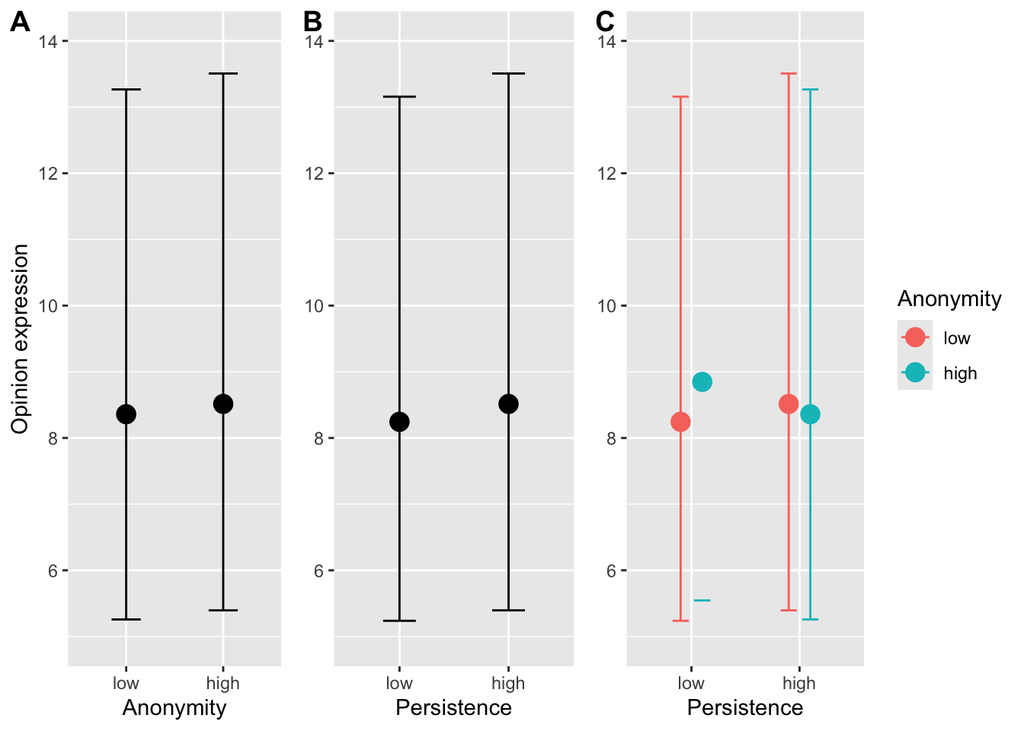

```r
p <- plot(
  conditional_effects(
    fit_fe_1
    ),
  ask = FALSE,
  plot = FALSE
  )

p_anon <-
  p[["anonymity_dev"]] +
  xlab("Anonymity") +
  ylab("Opinion expression") +
  scale_x_discrete(
    limits = rev
     ) +
  scale_y_continuous(
    limits = c(5, 14)
    , breaks = c(6, 8, 10, 12, 14)
    )

p_pers <-
  p[["persistence_dev"]] +
  xlab("Persistence") +
  ylab("Opinion expression") +
  scale_x_discrete(
    limits = rev
   ) +
  scale_y_continuous(
    limits = c(5, 14)
    , breaks = c(6, 8, 10, 12, 14)
    ) +
  theme(
    axis.title.y = element_blank()
    )

p_int <-
  p[["persistence_dev:anonymity_dev"]] +
  xlab("Persistence") +
  scale_x_discrete(
    limits = rev
     ) +
  scale_color_discrete(
    labels = c("low", "high")
    ) +
  guides(
    fill = "none",
    color = guide_legend(
      title = "Anonymity"
      )
    ) +
  theme(
    axis.title.y = element_blank()
    ) +
  scale_y_continuous(
    limits = c(5, 14)
    , breaks = c(6, 8, 10, 12, 14)
    )

plot <- cowplot::plot_grid(
  p_anon, p_pers, p_int,
  labels = c('A', 'B', "C"),
  nrow = 1,
  rel_widths = c(2, 2, 3)
  )

plot
```

```r
ggsave("figures/results.png", plot, width = 8, height = 4)
```

Shows that there are no main effects. There seems to be a (nonsignificant) interaction effect. In low persistence environment, anonymity is conducive to communication; in high it’s the opposite.

Let’s look at posteriors

```r
p_1 <-
  pp_check(fit_fe_1) +
  labs(title = "Zero-inflated poisson")
```

```
Using 10 posterior draws for ppc type 'dens_overlay' by default.
```

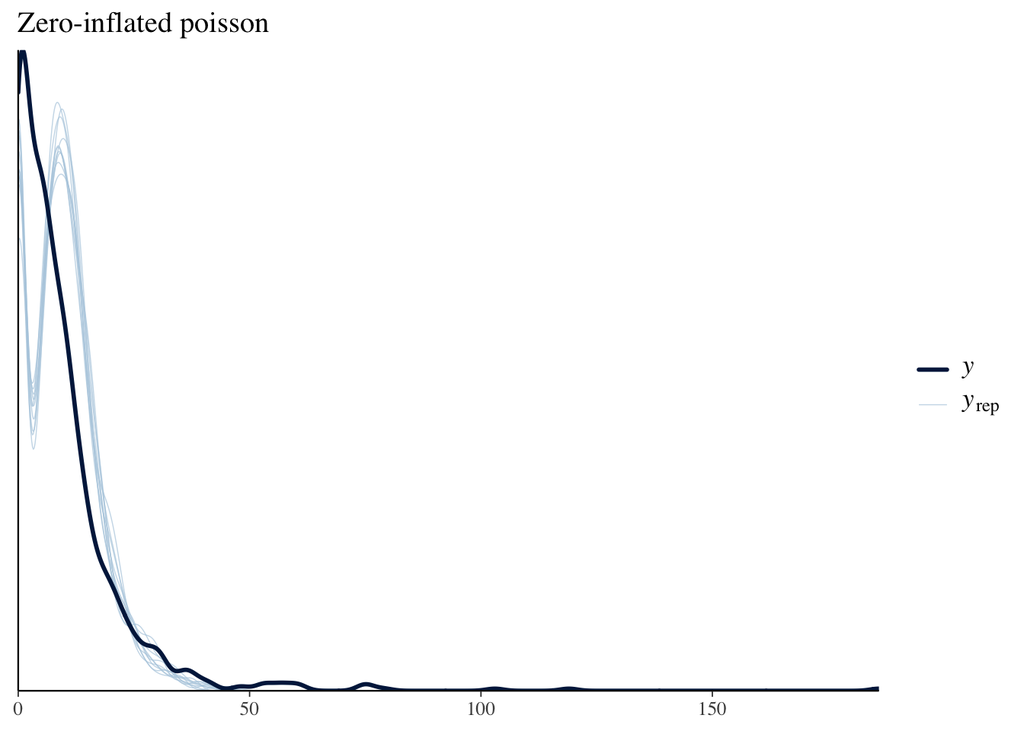

```r
p_1
```

The actual distribution cannot be precisely reproduced, but it’s also not too far off.

## Random effects

We preregistered to explore and compare models with random effects. So let’s model how the experimental conditions affect the outcomes differently depending on topic.

```r
fit_re_1 <-
  hush(
    brm(
      op_expr ~
        1 + persistence_dev * anonymity_dev + age + female + pol_stance +
        (1 + persistence_dev * anonymity_dev | topic) +
        (1 | topic:group)
      , data = d
      , chains = 4
      , cores = 4
      , iter = 6000
      , warmup = 2000
      , family = zero_inflated_poisson()
      , control = list(
        adapt_delta = .95
        , max_treedepth = 15
        )
      , save_pars = save_pars(all = TRUE)
    )
  )
```

```
Warning: There were 757 divergent transitions after warmup. See
https://mc-stan.org/misc/warnings.html#divergent-transitions-after-warmup
to find out why this is a problem and how to eliminate them.
```

```
Warning: Examine the pairs() plot to diagnose sampling problems
```

```
Warning: Tail Effective Samples Size (ESS) is too low, indicating posterior variances and tail quantiles may be unreliable.
Running the chains for more iterations may help. See
https://mc-stan.org/misc/warnings.html#tail-ess
```

Shows some convergence warnings.

Let’s inspect model.

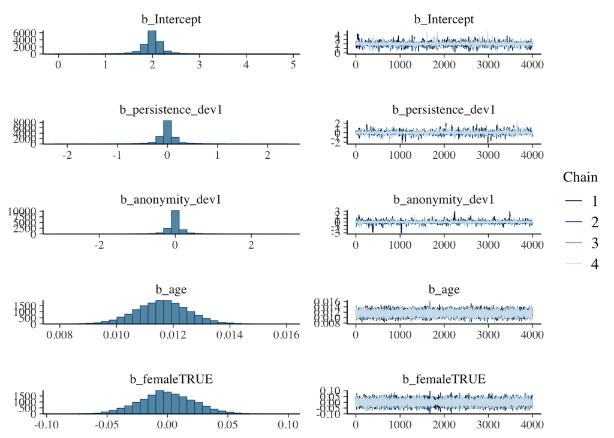

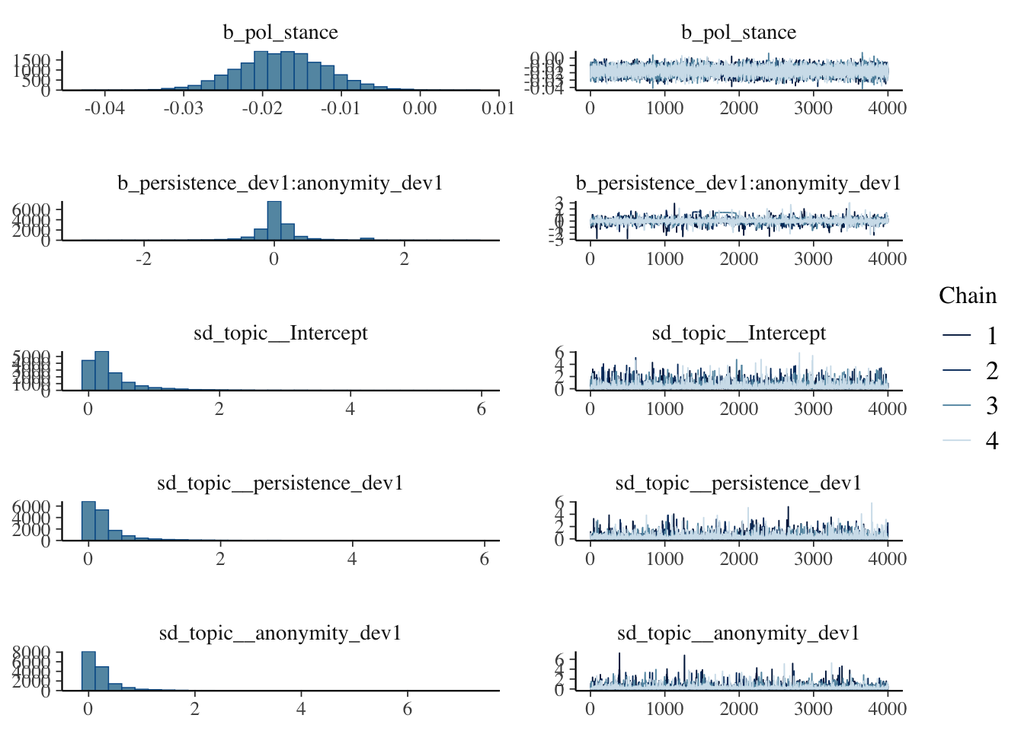

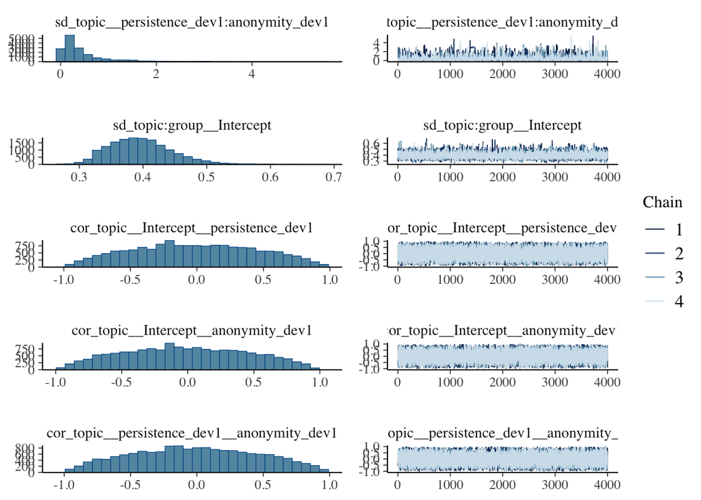

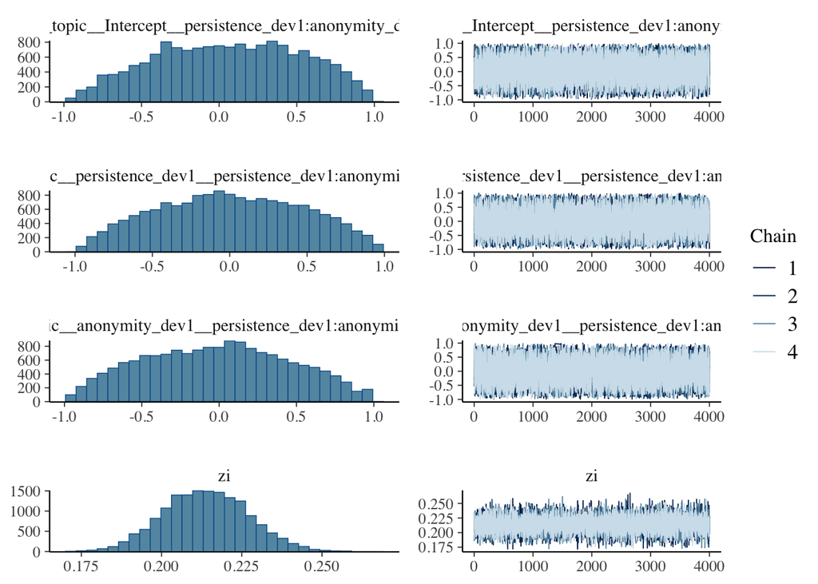

```r
plot(fit_re_1, ask = FALSE)
```

Traceplots look alright.

Let’s look at results.

```r
summary(fit_re_1)
```

```
 Family: zero_inflated_poisson
  Links: mu = log; zi = identity
Formula: op_expr ~ 1 + persistence_dev * anonymity_dev + age + female + pol_stance + (1 + persistence_dev * anonymity_dev | topic) + (1 | topic:group)
   Data: d (Number of observations: 960)
  Draws: 4 chains, each with iter = 6000; warmup = 2000; thin = 1;
         total post-warmup draws = 16000

Multilevel Hyperparameters:
~topic (Number of levels: 3)
                                                      Estimate Est.Error
sd(Intercept)                                             0.35      0.45
sd(persistence_dev1)                                      0.25      0.38
sd(anonymity_dev1)                                        0.25      0.40
sd(persistence_dev1:anonymity_dev1)                       0.44      0.53
cor(Intercept,persistence_dev1)                          -0.01      0.46
cor(Intercept,anonymity_dev1)                            -0.01      0.46
cor(persistence_dev1,anonymity_dev1)                     -0.01      0.46
cor(Intercept,persistence_dev1:anonymity_dev1)            0.06      0.46
cor(persistence_dev1,persistence_dev1:anonymity_dev1)     0.01      0.46
cor(anonymity_dev1,persistence_dev1:anonymity_dev1)      -0.01      0.46
                                                      l-95% CI u-95% CI Rhat
sd(Intercept)                                             0.01     1.64 1.00
sd(persistence_dev1)                                      0.00     1.34 1.00
sd(anonymity_dev1)                                        0.00     1.36 1.00
sd(persistence_dev1:anonymity_dev1)                       0.02     2.00 1.00
cor(Intercept,persistence_dev1)                          -0.83     0.82 1.00
cor(Intercept,anonymity_dev1)                            -0.83     0.82 1.00
cor(persistence_dev1,anonymity_dev1)                     -0.83     0.84 1.00
cor(Intercept,persistence_dev1:anonymity_dev1)           -0.79     0.86 1.00
cor(persistence_dev1,persistence_dev1:anonymity_dev1)    -0.83     0.84 1.00
cor(anonymity_dev1,persistence_dev1:anonymity_dev1)      -0.84     0.84 1.00
                                                      Bulk_ESS Tail_ESS
sd(Intercept)                                             3999     7589
sd(persistence_dev1)                                      3022     1235
sd(anonymity_dev1)                                        2973     4156
sd(persistence_dev1:anonymity_dev1)                        812     1075
cor(Intercept,persistence_dev1)                          18914    11709
cor(Intercept,anonymity_dev1)                            11052    10770
cor(persistence_dev1,anonymity_dev1)                     14598    12328
cor(Intercept,persistence_dev1:anonymity_dev1)            4205     1403
```

[output cut: 17 more lines]

```
Intercept                           5679     5933
persistence_dev1                    7250     6100
anonymity_dev1                      4316     4669
age                                17356    12335
femaleTRUE                         25008     9823
pol_stance                         14780    10789
persistence_dev1:anonymity_dev1      681      124

Further Distributional Parameters:
   Estimate Est.Error l-95% CI u-95% CI Rhat Bulk_ESS Tail_ESS
zi     0.21      0.01     0.19     0.24 1.00    16420    10765

Draws were sampled using sampling(NUTS). For each parameter, Bulk_ESS
and Tail_ESS are effective sample size measures, and Rhat is the potential
scale reduction factor on split chains (at convergence, Rhat = 1).
```

Again, no main or interaction effects.

Let’s see if the random effects model fits better

```r
cores <- parallel::detectCores()

fit_fe_1 <- add_criterion(
  fit_fe_1
  , "kfold"
  , K = 5
  , cores = cores
  )
```

```
Fitting model 1 out of 5
```

```
Fitting model 2 out of 5
```

```
Fitting model 3 out of 5
```

```
Fitting model 4 out of 5
```

```
Fitting model 5 out of 5
```

```r
fit_re_1 <- add_criterion(
  fit_re_1
  , "kfold"
  , K = 5
  , cores = cores
  )
```

```
Fitting model 1 out of 5
```

```
Fitting model 2 out of 5
```

```
Fitting model 3 out of 5
```

```
Fitting model 4 out of 5
```

```
Fitting model 5 out of 5
```

```r
comp_1 <- loo_compare(fit_fe_1, fit_re_1, criterion = "kfold")
comp_1
```

```
         elpd_diff se_diff
fit_re_1    0.0       0.0
fit_fe_1 -149.4      69.3
```

## Null-Model

Let’s also inspect a model without random intercepts to see if including random intercepts is worthwhile.

```r
fit_nm_1 <-
  hush(
    brm(
      op_expr ~
        1 + persistence_dev * anonymity_dev + age + female + pol_stance
      , data = d
      , chains = 4
      , cores = 4
      , iter = 6000
      , warmup = 2000
      , family = zero_inflated_poisson()
      , control = list(
        adapt_delta = .95
        , max_treedepth = 12
        )
      , save_pars = save_pars(all = TRUE)
      , silent = 2
      )
  )

summary(fit_nm_1)
```

```
 Family: zero_inflated_poisson
  Links: mu = log; zi = identity
Formula: op_expr ~ 1 + persistence_dev * anonymity_dev + age + female + pol_stance
   Data: d (Number of observations: 960)
  Draws: 4 chains, each with iter = 6000; warmup = 2000; thin = 1;
         total post-warmup draws = 16000

Regression Coefficients:
                                Estimate Est.Error l-95% CI u-95% CI Rhat
Intercept                           1.96      0.06     1.85     2.06 1.00
persistence_dev1                    0.00      0.01    -0.02     0.02 1.00
anonymity_dev1                     -0.04      0.01    -0.06    -0.02 1.00
age                                 0.01      0.00     0.01     0.01 1.00
femaleTRUE                          0.02      0.02    -0.02     0.07 1.00
pol_stance                         -0.01      0.01    -0.02     0.01 1.00
persistence_dev1:anonymity_dev1     0.02      0.01    -0.00     0.04 1.00
                                Bulk_ESS Tail_ESS
Intercept                          20193    13428
persistence_dev1                   20156    11001
anonymity_dev1                     20783    10932
age                                19306    11896
femaleTRUE                         20703    11806
pol_stance                         22715    12379
persistence_dev1:anonymity_dev1    20156    12002

Further Distributional Parameters:
   Estimate Est.Error l-95% CI u-95% CI Rhat Bulk_ESS Tail_ESS
zi     0.21      0.01     0.19     0.24 1.00    20932    11802

Draws were sampled using sampling(NUTS). For each parameter, Bulk_ESS
and Tail_ESS are effective sample size measures, and Rhat is the potential
scale reduction factor on split chains (at convergence, Rhat = 1).
```

Shows significant effect of anonymity on opinion expression.

Let’s compare models.

```r
fit_nm_1 <- add_criterion(
  fit_nm_1
  , "kfold"
  , K = 5
  , cores = cores
  )
```

```
Fitting model 1 out of 5
```

```
Fitting model 2 out of 5
```

```
Fitting model 3 out of 5
```

```
Fitting model 4 out of 5
```

```
Fitting model 5 out of 5
```

```r
comp_2 <- loo_compare(fit_fe_1, fit_nm_1, criterion = "kfold")
comp_2
```

```
         elpd_diff se_diff
fit_fe_1    0.0       0.0
fit_nm_1 -364.9     134.0
```

The model comparisons showed that the model with random intercepts fitted significantly better than the null model with fixed intercepts (Δ ELPD = -364.85, 95% CI [-627.549, -102.152].

## Hurdle

Let’s now estimate a fixed effects model with hurdles.

```r
fit_hrdl_1 <-
  hush(
    brm(
      bf(
        op_expr ~
          1 + persistence_dev * anonymity_dev + age + female + pol_stance +
          (1 | topic) +
          (1 | topic:group),
        zi ~
          1 + persistence_dev * anonymity_dev + age + female + pol_stance +
          (1 | topic) +
          (1 | topic:group)
      )
    , data = d
    , chains = 4
    , cores = 4
    , iter = 6000
    , warmup = 2000
    , family = zero_inflated_poisson()
    , control = list(
      adapt_delta = .95
      , max_treedepth = 15
      )
    )
  )
```

```
Warning: There were 422 divergent transitions after warmup. See
https://mc-stan.org/misc/warnings.html#divergent-transitions-after-warmup
to find out why this is a problem and how to eliminate them.
```

```
Warning: Examine the pairs() plot to diagnose sampling problems
```

```
Warning: Tail Effective Samples Size (ESS) is too low, indicating posterior variances and tail quantiles may be unreliable.
Running the chains for more iterations may help. See
https://mc-stan.org/misc/warnings.html#tail-ess
```

Again, some warnings.

Let’s inspect model.

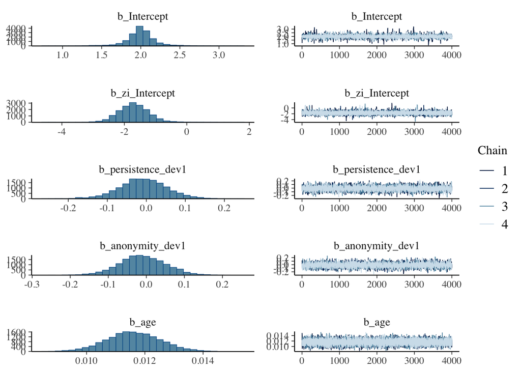

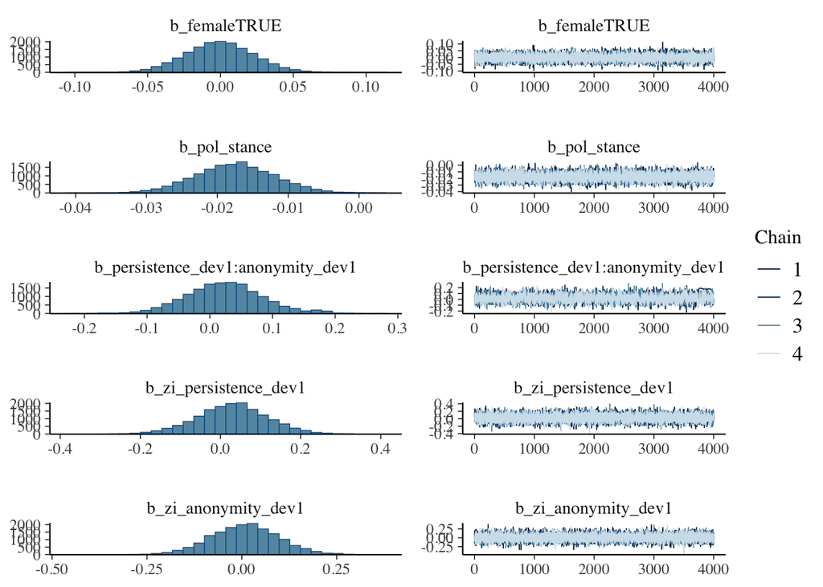

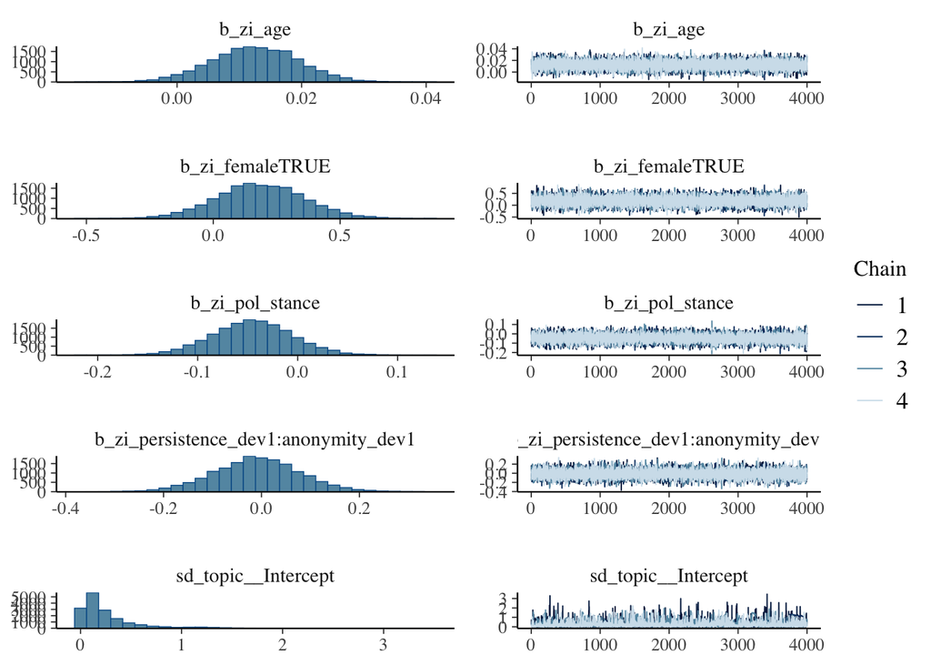

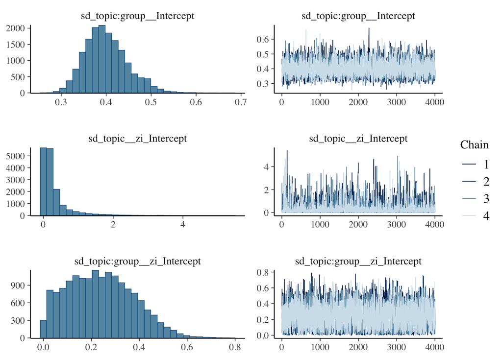

```r
plot(fit_hrdl_1, ask = FALSE)
```

Trace-plots look alright.

```r
summary(fit_hrdl_1)
```

```
 Family: zero_inflated_poisson
  Links: mu = log; zi = logit
Formula: op_expr ~ 1 + persistence_dev * anonymity_dev + age + female + pol_stance + (1 | topic) + (1 | topic:group)
         zi ~ 1 + persistence_dev * anonymity_dev + age + female + pol_stance + (1 | topic) + (1 | topic:group)
   Data: d (Number of observations: 960)
  Draws: 4 chains, each with iter = 6000; warmup = 2000; thin = 1;
         total post-warmup draws = 16000

Multilevel Hyperparameters:
~topic (Number of levels: 3)
                 Estimate Est.Error l-95% CI u-95% CI Rhat Bulk_ESS Tail_ESS
sd(Intercept)        0.26      0.31     0.01     1.20 1.00     1220      292
sd(zi_Intercept)     0.28      0.42     0.01     1.52 1.00     3380     4173

~topic:group (Number of levels: 48)
                 Estimate Est.Error l-95% CI u-95% CI Rhat Bulk_ESS Tail_ESS
sd(Intercept)        0.40      0.05     0.32     0.50 1.00     2278     1113
sd(zi_Intercept)     0.24      0.14     0.02     0.52 1.00     3893     7197

Regression Coefficients:
                                   Estimate Est.Error l-95% CI u-95% CI Rhat
Intercept                              2.00      0.18     1.60     2.39 1.01
zi_Intercept                          -1.69      0.49    -2.61    -0.72 1.00
persistence_dev1                      -0.01      0.06    -0.13     0.11 1.00
anonymity_dev1                        -0.01      0.06    -0.13     0.11 1.00
age                                    0.01      0.00     0.01     0.01 1.00
femaleTRUE                            -0.00      0.02    -0.05     0.05 1.00
pol_stance                            -0.02      0.01    -0.03    -0.01 1.00
persistence_dev1:anonymity_dev1        0.02      0.06    -0.09     0.16 1.01
zi_persistence_dev1                    0.03      0.09    -0.15     0.20 1.00
zi_anonymity_dev1                      0.01      0.09    -0.17     0.18 1.00
zi_age                                 0.01      0.01    -0.00     0.03 1.00
zi_femaleTRUE                          0.19      0.17    -0.15     0.53 1.00
zi_pol_stance                         -0.05      0.04    -0.12     0.04 1.00
zi_persistence_dev1:anonymity_dev1    -0.01      0.09    -0.18     0.17 1.00
                                   Bulk_ESS Tail_ESS
Intercept                              4517     2523
zi_Intercept                           8977     5131
persistence_dev1                       3100     2940
anonymity_dev1                         2296     5882
age                                   17399    12354
femaleTRUE                            19167    11310
pol_stance                            21511    10355
persistence_dev1:anonymity_dev1        1098      208
zi_persistence_dev1                   12625     3777
zi_anonymity_dev1                     15515    11855
zi_age                                17492    11736
zi_femaleTRUE                         19399    11393
zi_pol_stance                         19998    11223
zi_persistence_dev1:anonymity_dev1    15922    10687

Draws were sampled using sampling(NUTS). For each parameter, Bulk_ESS
and Tail_ESS are effective sample size measures, and Rhat is the potential
scale reduction factor on split chains (at convergence, Rhat = 1).
```

Same results, no main effects, slightly larger but still non-significant interaction effect.

# Exploratory Analyses

## Frequentist

Look at results from a frequentist perspective.

### Fixed effects

Estimate nested model.

```r
fit_fe_1_frq <-
  lmer(
    op_expr ~
      1 +
      (1 | topic/group) +
      persistence_dev * anonymity_dev + age + female + pol_stance
    , data = d
    )

summary(fit_fe_1_frq)
```

```
Linear mixed model fit by REML. t-tests use Satterthwaite's method [
lmerModLmerTest]
Formula: op_expr ~ 1 + (1 | topic/group) + persistence_dev * anonymity_dev +
    age + female + pol_stance
   Data: d

REML criterion at convergence: 7604

Scaled residuals:
   Min     1Q Median     3Q    Max
-1.484 -0.555 -0.196  0.264 13.549

Random effects:
 Groups      Name        Variance Std.Dev.
 group:topic (Intercept) 1.08e+01 3.28e+00
 topic       (Intercept) 8.92e-08 2.99e-04
 Residual                1.55e+02 1.25e+01
Number of obs: 960, groups:  group:topic, 48; topic, 3

Fixed effects:
                                Estimate Std. Error       df t value Pr(>|t|)
(Intercept)                       6.0450     2.1478 885.1185    2.81    0.005
persistence_dev1                 -0.0197     0.6214  43.8644   -0.03    0.975
anonymity_dev1                   -0.3437     0.6242  44.6401   -0.55    0.585
age                               0.0860     0.0357 943.4320    2.41    0.016
femaleTRUE                       -0.2434     0.8783 939.5946   -0.28    0.782
pol_stance                       -0.0319     0.2058 942.6445   -0.16    0.877
persistence_dev1:anonymity_dev1   0.1953     0.6226  44.1939    0.31    0.755

(Intercept)                     **
persistence_dev1
anonymity_dev1
age                             *
femaleTRUE
pol_stance
persistence_dev1:anonymity_dev1
---
Signif. codes:  0 '***' 0.001 '**' 0.01 '*' 0.05 '.' 0.1 ' ' 1

Correlation of Fixed Effects:
            (Intr) prss_1 anny_1 age    fmTRUE pl_stn
prsstnc_dv1  0.015
annymty_dv1  0.053  0.000
age         -0.750 -0.010 -0.049
femaleTRUE  -0.463 -0.014  0.041  0.252
pol_stance  -0.538 -0.009 -0.057 -0.003  0.062
prsstn_1:_1  0.019  0.000 -0.002 -0.045 -0.034  0.038
optimizer (nloptwrap) convergence code: 0 (OK)
boundary (singular) fit: see help('isSingular')
```

Quite weird that topic doesn’t get any variance at all. Perhaps due to small cluster size? With Bayesian estimation, it worked alright. Also, again no significant effects.

Estimate without nesting.

```r
fit_fe_2_frq <-
  lmer(
    op_expr ~
      1 +
      (1 | group) +
      persistence_dev * anonymity_dev + age + female + pol_stance + topic
    , data = d
    )

summary(fit_fe_2_frq)
```

```
Linear mixed model fit by REML. t-tests use Satterthwaite's method [
lmerModLmerTest]
Formula: op_expr ~ 1 + (1 | group) + persistence_dev * anonymity_dev +
    age + female + pol_stance + topic
   Data: d

REML criterion at convergence: 7598

Scaled residuals:
   Min     1Q Median     3Q    Max
-1.513 -0.548 -0.188  0.265 13.577

Random effects:
 Groups   Name        Variance Std.Dev.
 group    (Intercept)  11       3.32
 Residual             155      12.46
Number of obs: 960, groups:  group, 48

Fixed effects:
                                Estimate Std. Error       df t value Pr(>|t|)
(Intercept)                       6.3760     2.3261 511.8117    2.74   0.0063
persistence_dev1                 -0.0195     0.6257  41.8742   -0.03   0.9753
anonymity_dev1                   -0.3439     0.6284  42.6053   -0.55   0.5871
age                               0.0854     0.0357 942.0312    2.39   0.0169
femaleTRUE                       -0.2641     0.8788 938.1103   -0.30   0.7638
pol_stance                       -0.0324     0.2058 941.3972   -0.16   0.8751
topicgender                       0.4373     1.5334  41.9702    0.29   0.7769
topicmigration                   -1.3078     1.5329  41.9180   -0.85   0.3984
persistence_dev1:anonymity_dev1   0.1960     0.6268  42.1850    0.31   0.7561

(Intercept)                     **
persistence_dev1
anonymity_dev1
age                             *
femaleTRUE
pol_stance
topicgender
topicmigration
persistence_dev1:anonymity_dev1
---
Signif. codes:  0 '***' 0.001 '**' 0.01 '*' 0.05 '.' 0.1 ' ' 1

Correlation of Fixed Effects:
            (Intr) prss_1 anny_1 age    fmTRUE pl_stn tpcgnd tpcmgr
prsstnc_dv1  0.014
annymty_dv1  0.049  0.000
age         -0.701 -0.010 -0.049
femaleTRUE  -0.423 -0.014  0.041  0.252
pol_stance  -0.489 -0.009 -0.057 -0.004  0.063
topicgender -0.325  0.000 -0.001  0.017 -0.024 -0.020
topicmigrtn -0.337  0.000 -0.001  0.024  0.000 -0.016  0.500
prsstn_1:_1  0.018  0.000 -0.001 -0.045 -0.033  0.038 -0.001 -0.002
```

Also shows no significant effects.

For curiosity, estimate also without hierarchical structure.

```r
fit_fe_3_frq <-
  lm(
    op_expr ~
      1 +
      persistence_dev * anonymity_dev + topic + age + female + pol_stance
    , data = d
    )

summary(fit_fe_3_frq)
```

```
Call:
lm(formula = op_expr ~ 1 + persistence_dev * anonymity_dev +
    topic + age + female + pol_stance, data = d)

Residuals:
   Min     1Q Median     3Q    Max
-12.95  -7.46  -2.92   3.00 177.59

Coefficients:
                                Estimate Std. Error t value Pr(>|t|)
(Intercept)                       5.7503     2.2095    2.60   0.0094 **
persistence_dev1                 -0.0223     0.4148   -0.05   0.9571
anonymity_dev1                   -0.3598     0.4191   -0.86   0.3908
topicgender                       0.4291     1.0174    0.42   0.6733
topicmigration                   -1.3114     1.0166   -1.29   0.1974
age                               0.0901     0.0362    2.49   0.0129 *
femaleTRUE                       -0.2010     0.8932   -0.23   0.8220
pol_stance                        0.0398     0.2087    0.19   0.8489
persistence_dev1:anonymity_dev1   0.2004     0.4166    0.48   0.6306
---
Signif. codes:  0 '***' 0.001 '**' 0.01 '*' 0.05 '.' 0.1 ' ' 1

Residual standard error: 12.8 on 951 degrees of freedom
Multiple R-squared:  0.0115,    Adjusted R-squared:  0.00315
F-statistic: 1.38 on 8 and 951 DF,  p-value: 0.202
```

Also here, no significant effects.

## Gender

As preregistered, let’s see if effects differ across genders.

```r
fit_fe_gen <-
  hush(
    brm(
      op_expr ~
        1 + persistence_dev * anonymity_dev * gender + age + pol_stance +
        (1 | topic/group)
      , data = d
      , chains = 4
      , cores = 4
      , iter = 8000
      , warmup = 2000
      , family = zero_inflated_poisson()
      , control = list(
        adapt_delta = .95
        , max_treedepth = 12
        )
      )
  )
```

```
Warning: There were 603 divergent transitions after warmup. See
https://mc-stan.org/misc/warnings.html#divergent-transitions-after-warmup
to find out why this is a problem and how to eliminate them.
```

```
Warning: Examine the pairs() plot to diagnose sampling problems
```

Again, some warnings.

Let’s inspect model.

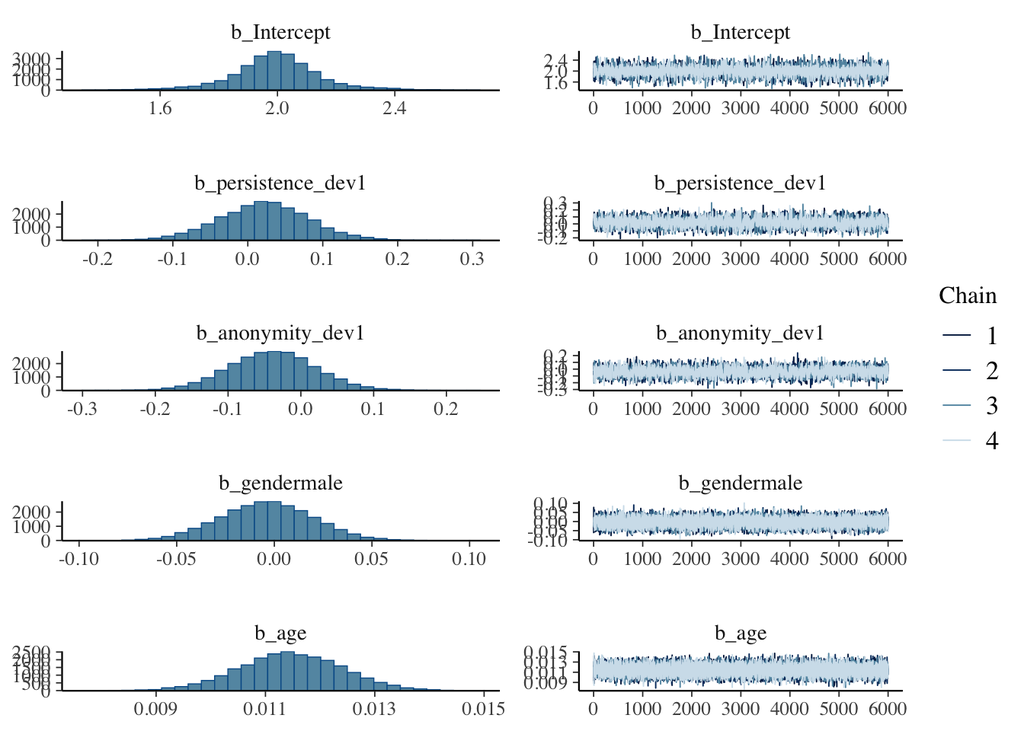

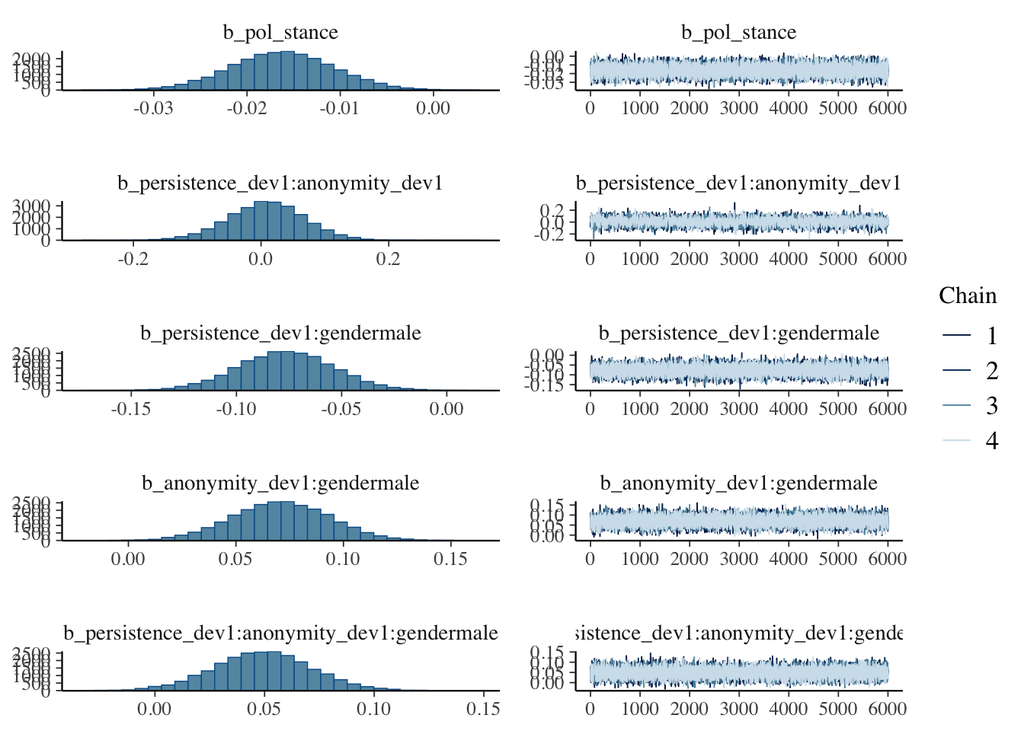

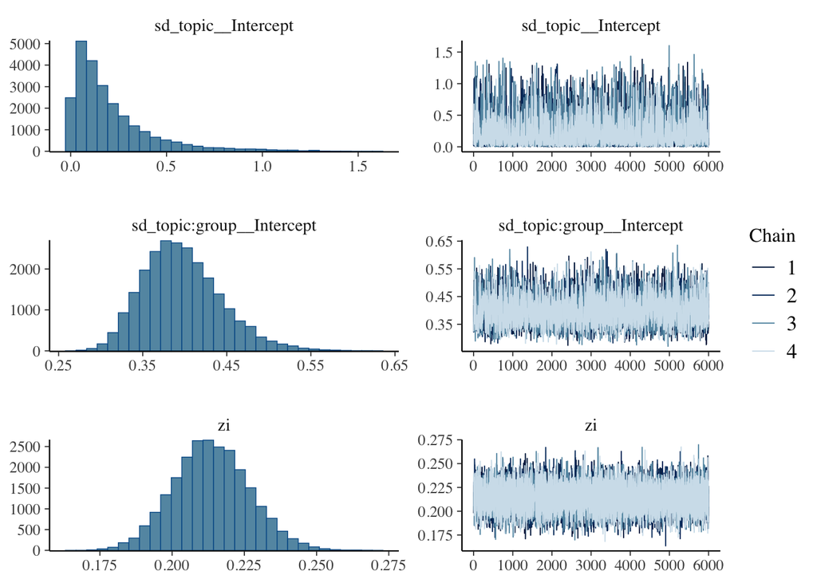

```r
plot(fit_fe_gen, ask = FALSE)
```

Traceplots look alright.

Let’s look at results.

```r
summary(fit_fe_gen)
```

```
 Family: zero_inflated_poisson
  Links: mu = log; zi = identity
Formula: op_expr ~ 1 + persistence_dev * anonymity_dev * gender + age + pol_stance + (1 | topic/group)
   Data: d (Number of observations: 960)
  Draws: 4 chains, each with iter = 8000; warmup = 2000; thin = 1;
         total post-warmup draws = 24000

Multilevel Hyperparameters:
~topic (Number of levels: 3)
              Estimate Est.Error l-95% CI u-95% CI Rhat Bulk_ESS Tail_ESS
sd(Intercept)     0.21      0.21     0.01     0.84 1.00     3091     4051

~topic:group (Number of levels: 48)
              Estimate Est.Error l-95% CI u-95% CI Rhat Bulk_ESS Tail_ESS
sd(Intercept)     0.40      0.05     0.32     0.50 1.00     3874     8425

Regression Coefficients:
                                           Estimate Est.Error l-95% CI u-95% CI
Intercept                                      1.99      0.15     1.67     2.32
persistence_dev1                               0.02      0.06    -0.10     0.14
anonymity_dev1                                -0.04      0.06    -0.16     0.08
gendermale                                    -0.00      0.02    -0.05     0.04
age                                            0.01      0.00     0.01     0.01
pol_stance                                    -0.02      0.01    -0.03    -0.01
persistence_dev1:anonymity_dev1                0.01      0.06    -0.11     0.12
persistence_dev1:gendermale                   -0.08      0.02    -0.12    -0.03
anonymity_dev1:gendermale                      0.07      0.02     0.03     0.11
persistence_dev1:anonymity_dev1:gendermale     0.05      0.02     0.00     0.09
                                           Rhat Bulk_ESS Tail_ESS
Intercept                                  1.00     5113     5226
persistence_dev1                           1.00     3885     6451
anonymity_dev1                             1.00     4466     6784
gendermale                                 1.00    12495     8754
age                                        1.00    16372     7194
pol_stance                                 1.00    15721    15008
persistence_dev1:anonymity_dev1            1.00     4269     7151
persistence_dev1:gendermale                1.00    13393    12807
anonymity_dev1:gendermale                  1.00    15059    13599
persistence_dev1:anonymity_dev1:gendermale 1.00    14762    13666

Further Distributional Parameters:
   Estimate Est.Error l-95% CI u-95% CI Rhat Bulk_ESS Tail_ESS
zi     0.21      0.01     0.19     0.24 1.00    14835    13287

Draws were sampled using sampling(NUTS). For each parameter, Bulk_ESS
and Tail_ESS are effective sample size measures, and Rhat is the potential
scale reduction factor on split chains (at convergence, Rhat = 1).
```

Indeed, several gender effects.

- For females, the effect of persistence is larger, that is more positive.
- For females, the effect of anonymity is smaller, that is more negative.
- For females, the interaction effect is also a bit smaller, that is more negative.

Let’s visualize results.

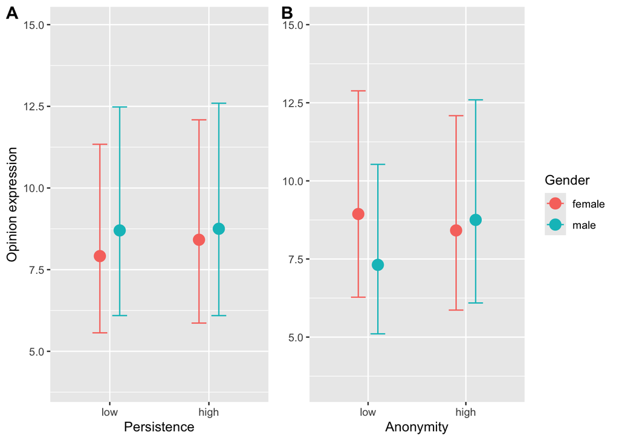

```r
p_gen <- plot(
  conditional_effects(
    fit_fe_gen
    ),
  ask = FALSE,
  plot = FALSE
  )

p_gen_pers <-
  p_gen[["persistence_dev:gender"]] +
  xlab("Persistence") +
  ylab("Opinion expression") +
  scale_y_continuous(
    limits = c(4, 15),
    breaks = c(5, 7.5, 10, 12.5, 15)
  ) +
  scale_x_discrete(
    limits = rev
  ) +
  guides(
    fill = "none"
    , color = "none"
    )

p_gen_anon <-
  p_gen[["anonymity_dev:gender"]] +
  xlab("Anonymity") +
  ylab("Opinion expression") +
  scale_y_continuous(
    limits = c(3.5, 15),
    breaks = c(5, 7.5, 10, 12.5, 15)
  ) +
  theme(
    axis.title.y = element_blank()
    ) +
  guides(
    fill = "none"
    ) +
  scale_x_discrete(
    limits = rev
  ) +
  scale_color_discrete(
    name = "Gender"
    )

plot_gen <- cowplot::plot_grid(
  p_gen_pers, p_gen_anon,
  labels = c('A', 'B'),
  nrow = 1,
  rel_widths = c(4, 5)
  )

plot_gen
```

```r
ggsave("figures/results_gen.png", plot_gen, width = 8, height = 4)
```

## Benefits

Let’s see if benefits differ across experimental groups.

We first look at the experimental group’s descriptives

```r
d |>
  group_by(persistence) |>
  summarize(benefits_m = mean(benefits, na.rm = TRUE)) |>
  as.data.frame() |>
  kable()
```

| persistence | benefits_m |
| --- | --- |
| high | 3.12 |
| low | 3.23 |

Looking at persistence, we see people with lower persistence reporting slightly higher benefits.

```r
d |>
  group_by(anonymity) |>
  summarize(benefits_m = mean(benefits, na.rm = TRUE)) |>
  as.data.frame() |>
  kable()
```

| anonymity | benefits_m |
| --- | --- |
| high | 3.15 |
| low | 3.20 |

Looking at anonymity, we see people with low anonymity reporting marginally higher benefits.

```r
d |>
  group_by(persistence, anonymity) |>
  summarize(benefits_m = mean(benefits, na.rm = T)) |>
  as.data.frame() |>
  kable()
```

| persistence | anonymity | benefits_m |
| --- | --- | --- |
| high | high | 3.07 |
| high | low | 3.18 |
| low | high | 3.22 |
| low | low | 3.23 |

Looking at both groups combined, we see that low anonymity and low persistence yielded highest benefits.

Let’s look if effects are significant.

```r
fit_fe_ben_1 <-
  hush(
    brm(
      benefits ~
        1 + persistence_dev * anonymity_dev  + age + female + pol_stance +
        (1 | topic/group)
      , data = d
      , chains = 4
      , cores = 4
      , iter = 6000
      , warmup = 2000
      , control = list(
        adapt_delta = .95
        , max_treedepth = 12
        )
      )
  )
```

Let’s inspect model.

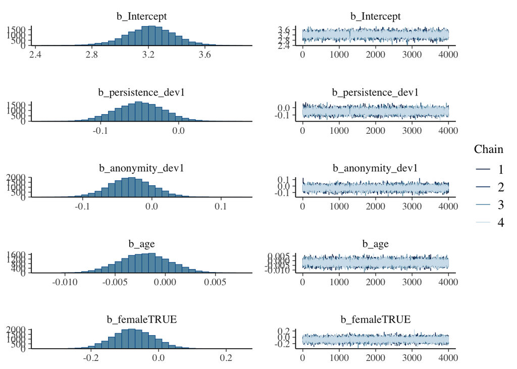

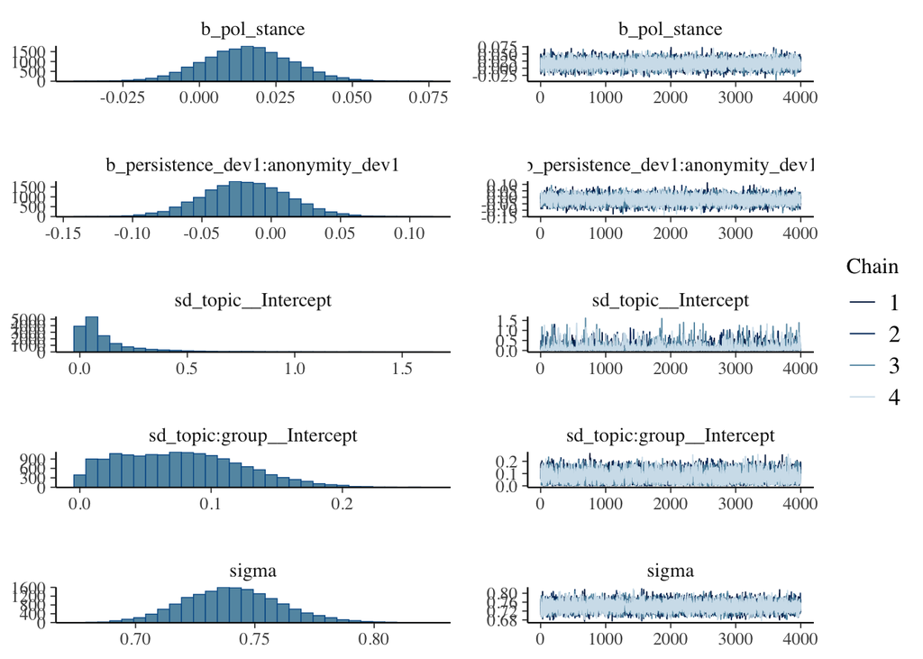

```r
plot(fit_fe_ben_1, ask = FALSE)
```

Traceplots look alright.

Let’s look at results.

```r
summary(fit_fe_ben_1)
```

```
 Family: gaussian
  Links: mu = identity; sigma = identity
Formula: benefits ~ 1 + persistence_dev * anonymity_dev + age + female + pol_stance + (1 | topic/group)
   Data: d (Number of observations: 705)
  Draws: 4 chains, each with iter = 6000; warmup = 2000; thin = 1;
         total post-warmup draws = 16000

Multilevel Hyperparameters:
~topic (Number of levels: 3)
              Estimate Est.Error l-95% CI u-95% CI Rhat Bulk_ESS Tail_ESS
sd(Intercept)     0.13      0.17     0.00     0.63 1.00     2141     2071

~topic:group (Number of levels: 48)
              Estimate Est.Error l-95% CI u-95% CI Rhat Bulk_ESS Tail_ESS
sd(Intercept)     0.08      0.05     0.00     0.17 1.00     3801     6162

Regression Coefficients:
                                Estimate Est.Error l-95% CI u-95% CI Rhat
Intercept                           3.21      0.17     2.85     3.55 1.00
persistence_dev1                   -0.05      0.03    -0.11     0.01 1.00
anonymity_dev1                     -0.03      0.03    -0.09     0.03 1.00
age                                -0.00      0.00    -0.01     0.00 1.00
femaleTRUE                         -0.07      0.06    -0.19     0.04 1.00
pol_stance                          0.02      0.01    -0.01     0.04 1.00
persistence_dev1:anonymity_dev1    -0.02      0.03    -0.08     0.04 1.00
                                Bulk_ESS Tail_ESS
Intercept                           2614      903
persistence_dev1                   10311     8192
anonymity_dev1                      9308     9903
age                                18813    12042
femaleTRUE                         13006     9174
pol_stance                         10421    10613
persistence_dev1:anonymity_dev1    10541     7780

Further Distributional Parameters:
      Estimate Est.Error l-95% CI u-95% CI Rhat Bulk_ESS Tail_ESS
sigma     0.74      0.02     0.70     0.78 1.00    12561     9668

Draws were sampled using sampling(NUTS). For each parameter, Bulk_ESS
and Tail_ESS are effective sample size measures, and Rhat is the potential
scale reduction factor on split chains (at convergence, Rhat = 1).
```

No significant effects. But note that effect of persistence on perceived benefits only marginally not significant.

## Costs

Let’s see if perceived differed across experimental groups.

We first look at the experimental group’s descriptives

```r
d |>
  group_by(persistence) |>
  summarize(costs = mean(costs, na.rm = TRUE)) |>
  as.data.frame() |>
  kable()
```

| persistence | costs |
| --- | --- |
| high | 1.99 |
| low | 1.99 |

Looking at persistence, we see both groups report equal costs.

```r
d |>
  group_by(anonymity) |>
  summarize(costs = mean(costs, na.rm = TRUE)) |>
  as.data.frame() |>
  kable()
```

| anonymity | costs |
| --- | --- |
| high | 1.89 |
| low | 2.09 |

Looking at anonymity, we see people with low anonymity report slightly higher costs.

```r
d |>
  group_by(persistence, anonymity) |>
  summarize(costs = mean(costs, na.rm = TRUE)) |>
  as.data.frame() |>
  kable()
```

| persistence | anonymity | costs |
| --- | --- | --- |
| high | high | 1.90 |
| high | low | 2.07 |
| low | high | 1.87 |
| low | low | 2.11 |

Looking at both groups combined, we see that highest costs were reported by group with low anonymity and low persistence.

Let’s look if effects are significant.

```r
fit_fe_costs_1 <-
  hush(
    brm(
      costs ~
        1 + persistence_dev * anonymity_dev + age + female + pol_stance +
        (1 | topic/group)
      , data = d
      , chains = 4
      , cores = 4
      , iter = 8000
      , warmup = 2000
      , control = list(
        adapt_delta = .95
        , max_treedepth = 12
        )
      )
  )
```

Let’s inspect model.

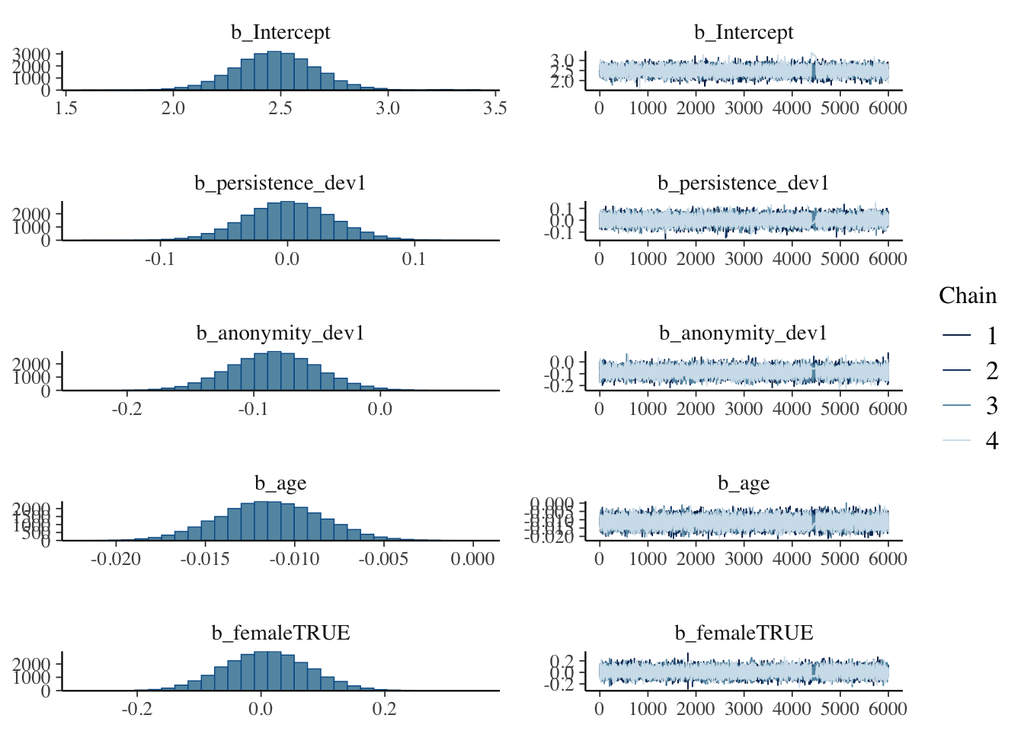

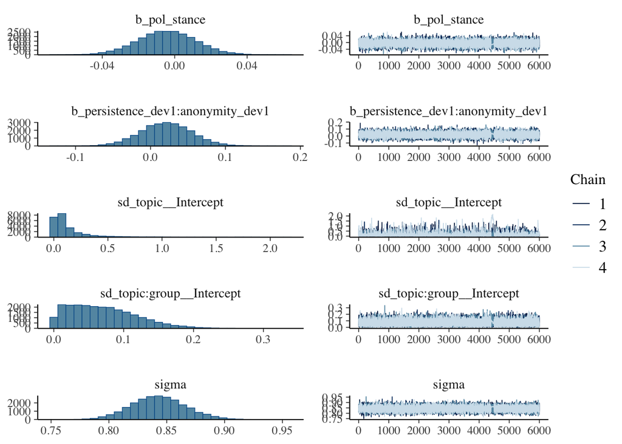

```r
plot(fit_fe_costs_1, ask = FALSE)
```

Traceplots look alright.

Let’s look at results.

```r
summary(fit_fe_costs_1)
```

```
 Family: gaussian
  Links: mu = identity; sigma = identity
Formula: costs ~ 1 + persistence_dev * anonymity_dev + age + female + pol_stance + (1 | topic/group)
   Data: d (Number of observations: 705)
  Draws: 4 chains, each with iter = 8000; warmup = 2000; thin = 1;
         total post-warmup draws = 24000

Multilevel Hyperparameters:
~topic (Number of levels: 3)
              Estimate Est.Error l-95% CI u-95% CI Rhat Bulk_ESS Tail_ESS
sd(Intercept)     0.13      0.19     0.00     0.66 1.00     3819     2147

~topic:group (Number of levels: 48)
              Estimate Est.Error l-95% CI u-95% CI Rhat Bulk_ESS Tail_ESS
sd(Intercept)     0.07      0.05     0.00     0.17 1.00     7146     9973

Regression Coefficients:
                                Estimate Est.Error l-95% CI u-95% CI Rhat
Intercept                           2.48      0.19     2.11     2.86 1.00
persistence_dev1                    0.00      0.03    -0.07     0.07 1.00
anonymity_dev1                     -0.08      0.03    -0.15    -0.02 1.00
age                                -0.01      0.00    -0.02    -0.01 1.00
femaleTRUE                          0.01      0.07    -0.12     0.14 1.00
pol_stance                         -0.00      0.02    -0.04     0.03 1.00
persistence_dev1:anonymity_dev1     0.02      0.03    -0.05     0.09 1.00
                                Bulk_ESS Tail_ESS
Intercept                           5196     2440
persistence_dev1                   26569    16662
anonymity_dev1                     25889    17303
age                                34343    18126
femaleTRUE                         25883    16648
pol_stance                         34809    17089
persistence_dev1:anonymity_dev1    24338    13993

Further Distributional Parameters:
      Estimate Est.Error l-95% CI u-95% CI Rhat Bulk_ESS Tail_ESS
sigma     0.84      0.02     0.80     0.89 1.00    30590    16079

Draws were sampled using sampling(NUTS). For each parameter, Bulk_ESS
and Tail_ESS are effective sample size measures, and Rhat is the potential
scale reduction factor on split chains (at convergence, Rhat = 1).
```

We find that anonymity does reduce costs.

## Mediation

Let’s see if perceived benefits and costs were associated with increased opinion expressions.

```r
fit_fe_med <-
  hush(
    brm(
      op_expr ~
        1 + persistence_dev * anonymity_dev + benefits + costs  + age + female + pol_stance +
        (1 | topic/group)
      , data = d
      , chains = 4
      , cores = 4
      , iter = 6000
      , warmup = 2000
      , family = zero_inflated_poisson()
      , control = list(
        adapt_delta = .95
        , max_treedepth = 12
        )
      )
  )
```

Let’s look at results.

```r
summary(fit_fe_med)
```

```
 Family: zero_inflated_poisson
  Links: mu = log; zi = identity
Formula: op_expr ~ 1 + persistence_dev * anonymity_dev + benefits + costs + age + female + pol_stance + (1 | topic/group)
   Data: d (Number of observations: 705)
  Draws: 4 chains, each with iter = 6000; warmup = 2000; thin = 1;
         total post-warmup draws = 16000

Multilevel Hyperparameters:
~topic (Number of levels: 3)
              Estimate Est.Error l-95% CI u-95% CI Rhat Bulk_ESS Tail_ESS
sd(Intercept)     0.19      0.23     0.01     0.86 1.00     2218     4466

~topic:group (Number of levels: 48)
              Estimate Est.Error l-95% CI u-95% CI Rhat Bulk_ESS Tail_ESS
sd(Intercept)     0.41      0.05     0.32     0.51 1.00     3002     4917

Regression Coefficients:
                                Estimate Est.Error l-95% CI u-95% CI Rhat
Intercept                           1.96      0.16     1.63     2.30 1.00
persistence_dev1                   -0.03      0.06    -0.14     0.09 1.00
anonymity_dev1                      0.00      0.06    -0.12     0.12 1.00
benefits                            0.11      0.02     0.08     0.14 1.00
costs                              -0.09      0.01    -0.12    -0.07 1.00
age                                 0.01      0.00     0.01     0.01 1.00
femaleTRUE                          0.00      0.02    -0.05     0.05 1.00
pol_stance                         -0.02      0.01    -0.03    -0.00 1.00
persistence_dev1:anonymity_dev1     0.02      0.06    -0.10     0.14 1.00
                                Bulk_ESS Tail_ESS
Intercept                           4690     4632
persistence_dev1                    2325     3690
anonymity_dev1                      2431     3821
benefits                           12168    11167
costs                              11977    10166
age                                21747    12851
femaleTRUE                         12484    10183
pol_stance                         11991     9162
persistence_dev1:anonymity_dev1     2662     4144

Further Distributional Parameters:
   Estimate Est.Error l-95% CI u-95% CI Rhat Bulk_ESS Tail_ESS
zi     0.08      0.01     0.06     0.10 1.00    12415    10719

Draws were sampled using sampling(NUTS). For each parameter, Bulk_ESS
and Tail_ESS are effective sample size measures, and Rhat is the potential
scale reduction factor on split chains (at convergence, Rhat = 1).
```

```r
anon_costs_a_b <- fixef(fit_fe_costs_1)["anonymity_dev1", "Estimate"]
anon_costs_a_se <- fixef(fit_fe_costs_1)["anonymity_dev1", "Est.Error"]
anon_costs_a_dis <- rnorm(10000, anon_costs_a_b, anon_costs_a_se)

anon_costs_b_b <- fixef(fit_fe_med)["benefits", "Estimate"]
anon_costs_b_se <- fixef(fit_fe_med)["benefits", "Est.Error"]
anon_costs_b_dis <- rnorm(10000, anon_costs_b_b, anon_costs_b_se)

anon_costs_ab_dis <- anon_costs_a_dis * anon_costs_b_dis
anon_costs_ab_m <- median(anon_costs_ab_dis)
anon_costs_ab_ll <- quantile(anon_costs_ab_dis, .025)
anon_costs_ab_ul <- quantile(anon_costs_ab_dis, .975)
```

# Save

```r
save.image("data/image.RData")
```